# Kiểm định và xây dựng mô hình dự đoán trong các tập dữ liêu Ung Thư Vú (Breast Cancer)

## 5.4. Bài Toán: Xây dựng mô hình dự đoán khối u là lành tính hay ác tính thông qua các chỉ số được nhập vào xử dụng Random Forest

- Đầu vào là các chỉ số
- Đầu ra là xác định đây là khối u lành tính hay ác tính với: 0 là M(malignant), 1 là B(benign)
- Sử dụng Random Forest.
- Chia dữ liệu thành huấn luyện và kiểm tra. 70% dành cho đào tạo, 30% dành cho kiểm tra.

```r
set.seed(123)

samp <- sample(nrow(data_copy), 0.7 * nrow(data_copy))

train <- data_copy[samp, ]

test <- data_copy[-samp, ]
```

- Mô hình sử dụng random forest:
- Lý do lựa chọn mô hình là: Bởi vì bài toán thuộc dạng phân lớp 0 ~ M và 1 ~ B. Ngoài ra em thấy có nhiều thuộc tính để training thì em thấy có một vài môt hình sử dụng được như là: decision tree, random forest,… Và cuối cùng em chọn radom forest để training bởi vì tính chất rất khó có khả năng gây ra overfitting. (Ngoại trừ khi tập dữ liệu bị sai.)

```r
# Check Something
ames_dt1 <- randomForest(diagnosis ~ `radius_mean`+`perimeter_mean`+`area_mean`+`concavity_mean`+`concave.points_mean`+ `fractal_dimension_se`+`texture_worst`+`perimeter_worst`+ `concavity_worst`,data = train,ntree = 800
)
ames_dt1
```

```
##
## Call:
##  randomForest(formula = diagnosis ~ radius_mean + perimeter_mean +      area_mean + concavity_mean + concave.points_mean + fractal_dimension_se +      texture_worst + perimeter_worst + concavity_worst, data = train,      ntree = 800)
##                Type of random forest: regression
##                      Number of trees: 800
## No. of variables tried at each split: 3
##
##           Mean of squared residuals: 0.03764961
##                     % Var explained: 83.43
```

- Chọn ngưỡng cây(n=800) Làm sao để kiếm được ngưỡng tối ưu nhất: ntree = 800 ? (Dựa vào biểu đồ)

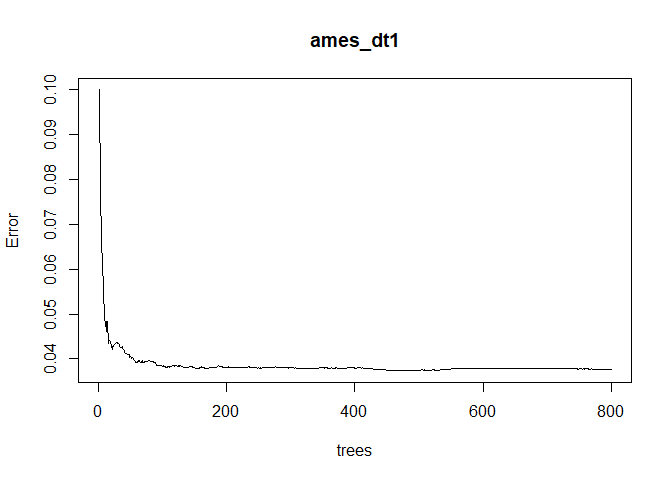

```r
plot(ames_dt1)
```

- Predicting the Test set results

```r
y_pred <- predict(ames_dt1, newdata = test)
```

```r
head(y_pred)
```

```
##         1         2         9        15        17        18
## 0.8646875 0.9922500 0.9881042 0.9507917 0.7162292 1.0000000
```

- Trình bày biểu đồ dữ liệu ở đây trước khi làm tròn:

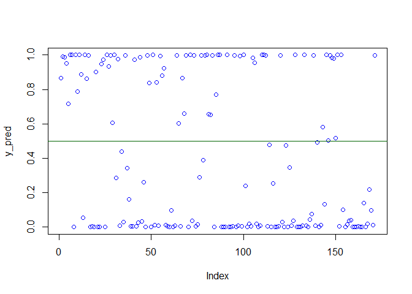

```r
plot(y_pred,col = "blue")
abline(h = 0.5, col = "darkgreen")
```

- Làm tròn dữ liệu

```r
y_pred<-round(y_pred)
head(y_pred)
```

```
##  1  2  9 15 17 18
##  1  1  1  1  1  1
```

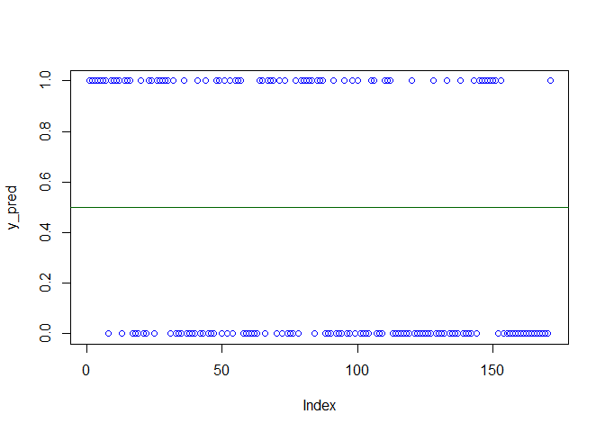

```r
plot(y_pred,col = "blue")
abline(h = 0.5, col = "darkgreen")
```

- Kiểm tra lỗi
- Sử dụng Confusion matrix

```r
table(test$diagnosis,y_pred)
```

```
##    y_pred
##      0  1
##   0 95  3
##   1  4 69
```

- Ta có:
- Giá trị dự doán đúng cho 0 ~ M là: 95
- Giá trị dự đoán sai cho 0 ~ M là: 3
- Giá trị dự doán đúng cho 1 ~ B là: 69
- Giá trị dự đoán sai cho 1 ~ B là: 4
- calculate sensitivity ~ true positive rate

```r
sensitivity(factor(test$diagnosis),factor(y_pred))
```

```
## [1] 0.959596
```

- calculate specificity ~ true negative rate

```r
specificity(factor(test$diagnosis),factor(y_pred))
```

```
## [1] 0.9583333
```

- Kiểm tra lỗi
- Kiểm tra lỗi thông qua mean: ~ Mean percentage error

```r
sum(test$diagnosis - y_pred)/length(test)
```

```
## [1] 0.03225806
```

- Kiểm tra lỗi thông qua mean: ~ Abs Mean percentage error

```r
sum(abs(test$diagnosis - y_pred))/length(test)
```

```
## [1] 0.2258065
```

- Cách mà RandomForest hoạt động đối với tập dữ liệu:

** Cách mà RandomForest hoạt động:

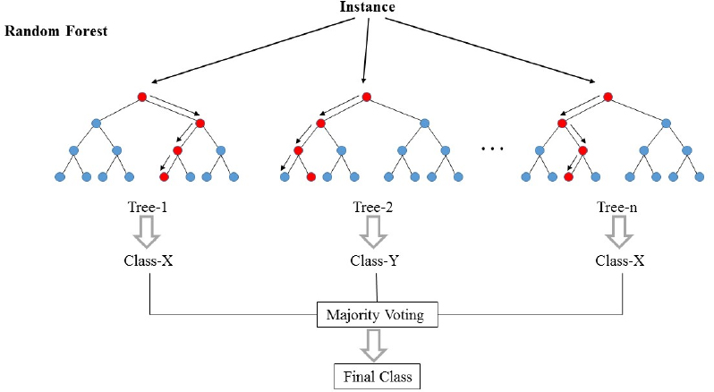

```r
knitr::include_graphics("./Image/Random Forest.jpg")
```

- Thông tin thêm về Random Forest:
- Entropy: Nó là thước đo tính ngẫu nhiên hoặc không thể đoán trước trong tập dữ liệu.

```r
knitr::include_graphics("./Image/Entropy.PNG")
```

[output not shown]

- Information Gain: Thước đo mức độ giảm entropy sau khi tập dữ liệu được phân chia là mức tăng thông tin.
- Leaf Node: Nút lá là nút mang sự phân loại hoặc quyết định.
- Decision Node: Một nút có hai hoặc nhiều nhánh.
- Root Node: Nút gốc là nút quyết định trên cùng, là nơi bạn có tất cả dữ liệu của mình.
- In ra hình ảnh rừng.(mang tính tương đối.)

```r
png(file="./Image/saving_plot2.png",
width=4000, height=900)
reprtree:::plot.getTree(ames_dt1)
dev.off()
```

- Hiển thị ảnh:

[figure not shown]

```r
knitr::include_graphics("./Image/saving_plot2.png")
```